# Ajuste a distribuciones

## Pruebas de normalidad

### Test de Shapiro-Wilk

La prueba de Shapiro-Wilk es una de las más utilizadas y eficientes para comprobar la normalidad de una variable, auarnque el tamaño de la muestra debe ser menor de 5000. En caso de tener más pueden usarse alguna de las muchas pruebas de normalidad que hay.

```r
# Test de normalidad de Shapiro-Wilk
set.seed(10)
x <- rnorm(100) # Creamos una variable normal con 100 valores
x.test <- shapiro.test(x)
print(x.test)
```

```
    Shapiro-Wilk normality test

data:  x
W = 0.98908, p-value = 0.5911
```

```r
x2 <- runif(100) # Creamos una variable con distribución uniforme (no normal) con 100 valores
x2.test <- shapiro.test(x2)
print(x2.test)
```

```
    Shapiro-Wilk normality test

data:  x2
W = 0.92848, p-value = 4.082e-05
```

Shapiro-Wilk normality test

data: x W = 0.9891, p-value = 0.5911 Como p > 0.05 no podemos rechazar que la distribución sea normal.

```
Shapiro-Wilk normality test
```

data: x2 W = 0.9285, p-value = 4.082e-05

En este caso p < 0.05 por lo que podemos rechazar que la distribución sea de tipo normal.

Podemos hacer unos gráficos superponiendo la distribución normal al histograma de frecuencias. Para ello hemos creado la función plotn() que lo hace. Es fácil modificarla para añadir más opciones para los gráficos.

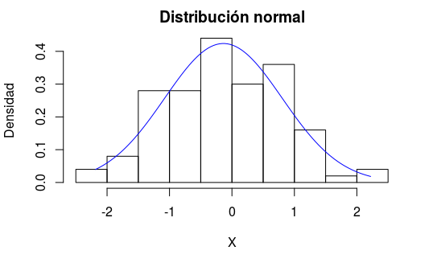

```r
# Dado un vector dibuja el histograma asociado y la distribución normal

plotn <- function(x,main="Histograma de frecuencias \ny distribución normal",
                  xlab="X",ylab="Densidad") {
  min <- min(x)
  max <- max(x)
  media <- mean(x)
  dt <- sd(x)

  hist(x,freq=F,main=main,xlab=xlab,ylab=ylab)
  curve(dnorm(x,media,dt), min, max,add = T,col="blue")
}

plotn(x,main="Distribución normal")
```

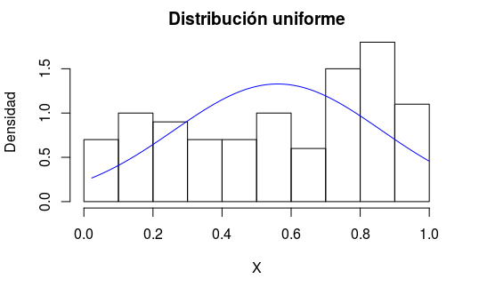

```r
plotn(x2,main="Distribución uniforme")
```

### Test de Lilliefors

Esta prueba de normalidad requiere la librería nortest.

Lilliefors (Kolmogorov-Smirnov) normality test

data: x D = 0.0471, p-value = 0.8461

```
Lilliefors (Kolmogorov-Smirnov) normality test
```

data: x2 D = 0.1226, p-value = 0.0008086

### Test de Anderson-Darling

La prueba de Anderson-Darling necesita la librería nortest.

Anderson-Darling normality test

data: x A = 0.3046, p-value = 0.5636

```r
# Creamos una variable con distribución uniforme (no normal) con 100 valores
x2 <- runif(100)
x2.test <- ad.test(x2)
x2.test
```

```
Anderson-Darling normality test
```

data: x2 A = 2.2429, p-value = 9.982e-06

### Test binomial para dos frecuencias

El test binomial se utiliza para ver si una variable con dos estados (como la cara y cruz de una moneda) se ajusta a una probabilidad determinada.

data: 14 and 20 number of successes = 14, number of trials = 20, p-value = 0.1153 alternative hypothesis: true probability of success is not equal to 0.5 95 percent confidence interval: 0.4572108 0.8810684 sample estimates: probability of success 0.7

Como p-value > 0.05 debemos concluir que entra dentro de lo posible obtener este resultado

```
Exact binomial test
```

data: 12 and 30 number of successes = 12, number of trials = 30, p-value = 0.002032 alternative hypothesis: true probability of success is not equal to 0.1666667 95 percent confidence interval: 0.2265576 0.5939651 sample estimates: probability of success 0.4

Como p-value < 0.05 el resultado obtenido no se ajusta a lo esperado en un dado.